# Jolee_Markdown

Jolee Thirtyacre, Connor Whalen

2024-07-17

### General instructions for R Markdown

- For helpful instructions on how to start using R Markdown, visit [this link] (https://fish497.github.io/website/lectures/week_07/intro_rmarkdown.html).
- To insert code chunks, press command+option+i (mac), ctrl+alt+i (windows)
- Anything inside a code chunk will run as normal code, anything outside a code chunk will appear in the document as plain text.

# Questions we are asking:

1. Is increased parasitism associated with decreased body condition?
- This is complicated because we are proposing an observational study and the causality that we are attempting to describe can go in both directions. Fish that have high parasitism could be skinner, but also skinner fish could be more susceptible to increased parasitism. We won’t be able to parse this out using our dataset, but it is still an interesting question worth answering. We just need to be careful to not make any absolute statements based on this (which is why we use the language ‘associated’ instead of ‘affected by’).
- There is the element of time that we can incorporate into this as well, which is to say that we could look at body condition over time and see what trends exist. If there are any non-linear trends in body condition through time (meaning it doesn’t just go down or just go up or just stay the same), we can then incorporate the variable of parasite presence/burden to see if there is any correlation between the non-linear changes in body condition and parasite counts. This would basically look like on a graph, you have a big drop in body size followed a period of time later by an increase in parasite presence in these fish, you could say something like skinnier fish are associated with an increased parasite burden, since we would see that some event caused body size to decrease and as a result there was more parasites in the fish. But again we have to be really careful to not imply causation if all we have is correlation. Chelsea said she would be surprised if we noticed this effect, but it could be worth looking at anyway.
2. Is the type of parasite important in determining whether parasitism is associated with decreased body condition?
- Parasites exist in different parts of the body based on what they are: monogenes will always be on the gills, adult trematodes and adult cestodes will always be in the intestines, metacercariae can be most anywhere on the body, etc.
- To answer this question, we would need to go through the data and identify what parasites are in their adult stage versus their larval stage. This would involve a bit of research into what the different (larval or adult) stages are present for each of the ones we have found. You would then be also able to look at the literature to see where that parasite would live within the fish at that stage in its life cycle, and then we could make commentaries about how different stages/types of parasites could be associated with changes to body condition. For example, if we had a ton of adult cestodes in the intestine and found that fish to have a very bad condition score, we could talk about how adult cestodes require more nutrients based on their big size, etc.

## Methods

We removed “one-off” species as defined by appearing less than five times across all species datasets and if the parasite also exists in its own group (e.g., We found four acanthacephalean species across four fish species, so acanths were removed because less than five were found and they exist in a seperate group from other parasites. e.g., TREM.META was kept because even though it only appeared once in the H. nuchalis dataset, it will be lumped in with the other trematode metacercaria data points.)

#### Rules for discriminating between adult and larval:

- For any parasite we have identified to a specific taxonomic level (family, genus, etc.), we will look at that life cycle in the literature and ID what stage we have.
- Anything labeled as META or CYST are considered larval, as metacercaria and cysts are by definition non-final adult forms of parasites.
- Anything labeled as TREM, NEM, ACANTH, MONO, COPE, or CEST are considered adults of those groups, as we were able to ID them to larger taxonomic groups because they were not in cysts.
- lists in the code below are the complete lists of which parasites are considered adult or larval

#### Fulton’s Condition Factor Equation:

| Variable | Definition |
| --- | --- |
| K | Fulton’s Condition Factor (<1=good, >1=bad) |
| W | weight of host fish (in grams) |
| SL | standard length of fish (in millimeters) |

$$K_i = W/SL^3 *10^5$$

## Code for Analyses

#### Load packages

```r
library(ggeffects)
library(tidyverse)
library(lmerTest)
library(emmeans)
library(broom)
library(ggpubr)
library(stringr)
library(caret)
library(tibble)
library(car)
library(tidyr)
library(readr)
library(dbplyr)
library(lubridate)
library(ggplot2)
library(glmmTMB)
library(DHARMa)
library(scales)
library(ggpmisc)
```

# Question 1

### Giving adult and larval IDs so we can look at life stage compared to total parasite burden (for answering question 1). Create a column in each dataset for weight in grams

- add columns to identify species as an adult or larval stage and new column for total parasite count

```r
P.vigilax.data <- P.vigilax.data %>%
  mutate(adult = rowSums(select(.,
                      "acanth_bigb",
                      "acanth_bkr",
                      "nem_cona",
                      "nem_cap",
                      "nem_dich",
                      "nem_larv",
                      "nem_trbk",
                      "nem_unk",
                      "cest_godz",
                      "cest_ntg",
                      "cope_cl",
                      "cope_grab",
                      "cest_pea",
                      "cest_l",
                      "cest_vit",
                      "cest_unk",
                      "mono_gyro",
                      "mono_dact",
                      "mono_lg",
                      "trem_rnda",
                      "trem_unk"))) %>%
  mutate(larval = rowSums(select(.,
                      "meta_hs",
                      "meta_unk",
                      "myx_go",
                      "cest_comp",
                      "myx_geom",
                      "myxo_bc",
                      "myx_thel",
                      "myxo_sbad",
                      "myxo_unk",
                      "myxo_up",
                      "trem_met",
                      "trem_sss",
                      "trem_buc",
                      "trem_metaf",
                      "trem_metags",
                      "trem_ms",
                      "trem_nea"))) %>%
  mutate(adult = as.integer(adult)) %>%
  mutate(larval = as.integer(larval)) %>%
  mutate(psite_count = rowSums(select(.,
                                      "adult",
                                      "larval"))) %>%
  mutate(weight_g = (weight_mg/1000)) %>%
  janitor::clean_names()

####
I.punctatus.data <- I.punctatus.data %>%
  mutate(larval = rowSums(select(.,
                      "nem_cyst",
                      "trem_meta_gg",
                      "trem_meta_unk",
                      "trem_lg",
                      "nem_cyst",
                      "cest_comp",
                      "myx_tail",
                      "myx_geom"))) %>%
  mutate(adult = rowSums(select(.,
                      "acan_ostr",
                      "cest_meg",
                      "leech_kut",
                      "nem_nmts",
                      "mono_ip",
                      "mono_unk",
                      "nem_phar",
                      "nem_pty",
                      "nem_sp",
                      "nem_taf",
                      "nem_unk",
                      "nmorph",
                      "trem_2",
                      "trem_allo",
                      "trem_ble",
                      "trem_crep",
                      "trem_f",
                      "trem_lip",
                      "trem_megict",
                      "trem_smile",
                      "trem_unk"))) %>%
  select(-nmorph, -leech_kut) %>%
  mutate(adult = as.integer(adult)) %>%
  mutate(larval = as.integer(larval)) %>%
  mutate(psite_count = rowSums(select(.,
                                      "adult",
                                      "larval"))) %>%
  mutate(weight_g = (weight_mg/1000)) %>%
  janitor::clean_names()

####
N.atherinoides.data <- N.atherinoides.data %>%
  mutate(larval = rowSums(select(.,
                      "nem_cyst",
                      "trem_larv",
                      "trem_meta",
                      "myx_sp",
                      "cest_comp",
                      "cest_lvs",
                      "myx_round",
                      "trem_cyst"))) %>%#
  mutate(adult = rowSums(select(.,
                      "cest_hyd",
                      "cest_tri",
                      "cope_a",
                      "mono_all",
                      "mono_unk",
                      "nem_bran",
                      "nem_cap",
                      "nem_spky",
                      "nem_tfs",
                      "nem_twas",
                      "nem_unkn",
                      "trem_gb",
                      "trem_l"))) %>%
  mutate(adult = as.integer(adult)) %>%
  mutate(larval = as.integer(larval)) %>%
  mutate(psite_count = rowSums(select(.,
                                      "adult",
                                      "larval"))) %>%
  mutate(weight_g = (weight_mg/1000)) %>%
  janitor::clean_names()

####
H.nuchalis.data <- H.nuchalis.data %>%
  mutate(larval = rowSums(select(.,
                      "nem_daft",
                      "trem_cm",
                      "trem_meta_het",
                      "trem_meta_sp",
                      "trem_bc",
                      "trem_meta_go",
                      "trem_meta_es",
                      "meta_unk",
                      "trem_meta",
                      "trem_meta_unk",
                      "myx_ak",
                      "myx_fi",
                      "myx_tin",
                      "myx_gl",
                      "myx_ot",
                      "myx_eye",
                      "myx_gc"))) %>%#
  mutate(adult = rowSums(select(.,
                      "cest_bb",
                      "nem_unk",
                      "trem_ass",
                      "trem_ns",
                      "trem_diplo",
                      "trem_unk",
                      "cest_unk",
                      "mono_dact",
                      "mono_gdac",
                      "acan_ad",
                      "cope_pood"))) %>%
  mutate(adult = as.integer(adult)) %>%
  mutate(larval = as.integer(larval)) %>%
  mutate(psite_count = rowSums(select(.,
                                      "adult",
                                      "larval"))) %>%
  mutate(weight_g = (weight_mg/1000)) %>%
  janitor::clean_names()
```

### Calculating Fulton’s Condition Factor

```r
P.vigilax.data.fcf <- P.vigilax.data %>%
  mutate(body_index_pimvig = ((P.vigilax.data$weight_g/((P.vigilax.data$standard_length_mm)^3)))*(10^5)) %>%
  janitor::clean_names()

I.punctatus.data.fcf <- I.punctatus.data %>%
  mutate(body_index_ictpun = ((I.punctatus.data$weight_g/((I.punctatus.data$standard_length_mm)^3)))*(10^5)) %>%
  janitor::clean_names()

N.atherinoides.data.fcf <- N.atherinoides.data %>%
  mutate(body_index_notath = ((N.atherinoides.data$weight_g/((N.atherinoides.data$standard_length_mm)^3)))*(10^5)) %>%
  janitor::clean_names()

H.nuchalis.data.fcf <- H.nuchalis.data %>%
  mutate(body_index_hybnuc = ((H.nuchalis.data$weight_g/((H.nuchalis.data$standard_length_mm)^3)))*(10^5)) %>%
  janitor::clean_names()
```

#### Model formula for Question 1

$$K_i\sim parasite\ count\ + ci$$
- impact category is anything below the pulp mill - control category is anything above the pulp mill #### Test model for question 1 - run models

```r
# run models
summary(fcf_pimvig_lm <- lm(body_index_pimvig ~ psite_count + ci, data = P.vigilax.data.fcf)) ### @ a = 0.1 ## the value for the CI significance has somehow changed and now it is not significant? no idea why: nothing was changed in the code or the datasets
```

```
##
## Call:
## lm(formula = body_index_pimvig ~ psite_count + ci, data = P.vigilax.data.fcf)
##
## Residuals:
##      Min       1Q   Median       3Q      Max
## -0.49617 -0.20574 -0.05533  0.14569  1.14517
##
## Coefficients:
##              Estimate Std. Error t value Pr(>|t|)
## (Intercept) 1.5169737  0.1165717  13.013   <2e-16 ***
## psite_count 0.0002304  0.0016169   0.143    0.887
## ciimpact    0.1952092  0.1227920   1.590    0.119
## ---
## Signif. codes:  0 '***' 0.001 '**' 0.01 '*' 0.05 '.' 0.1 ' ' 1
##
## Residual standard error: 0.3479 on 43 degrees of freedom
##   (147 observations deleted due to missingness)
## Multiple R-squared:  0.05621,    Adjusted R-squared:  0.01231
## F-statistic:  1.28 on 2 and 43 DF,  p-value: 0.2883
```

```r
summary(fcf_ictpun_lm <- lm(body_index_ictpun ~ psite_count + ci, data = I.punctatus.data.fcf))
```

```
##
## Call:
## lm(formula = body_index_ictpun ~ psite_count + ci, data = I.punctatus.data.fcf)
##
## Residuals:
##      Min       1Q   Median       3Q      Max
## -0.52047 -0.18795 -0.00736  0.12285  1.02575
##
## Coefficients:
##               Estimate Std. Error t value Pr(>|t|)
## (Intercept)  1.5136846  0.0514573  29.416   <2e-16 ***
## psite_count -0.0004773  0.0007097  -0.672    0.504
## ciimpact    -0.0469521  0.0633193  -0.742    0.461
## ---
## Signif. codes:  0 '***' 0.001 '**' 0.01 '*' 0.05 '.' 0.1 ' ' 1
##
## Residual standard error: 0.2551 on 69 degrees of freedom
##   (17 observations deleted due to missingness)
## Multiple R-squared:  0.01543,    Adjusted R-squared:  -0.01311
## F-statistic: 0.5408 on 2 and 69 DF,  p-value: 0.5848
```

```r
summary(fcf_notath_lm <- lm(body_index_notath ~ psite_count + ci, data = N.atherinoides.data.fcf)) ### @ a = 0.1
```

```
##
## Call:
## lm(formula = body_index_notath ~ psite_count + ci, data = N.atherinoides.data.fcf)
##
## Residuals:
##      Min       1Q   Median       3Q      Max
## -0.72500 -0.08442 -0.00279  0.07689  0.61192
##
## Coefficients:
##               Estimate Std. Error t value Pr(>|t|)
## (Intercept)  0.9294070  0.0199884  46.497   <2e-16 ***
## psite_count -0.0005757  0.0006244  -0.922   0.3579
## ciimpact     0.0444311  0.0245886   1.807   0.0726 .
## ---
## Signif. codes:  0 '***' 0.001 '**' 0.01 '*' 0.05 '.' 0.1 ' ' 1
##
## Residual standard error: 0.1535 on 164 degrees of freedom
##   (41 observations deleted due to missingness)
## Multiple R-squared:  0.02299,    Adjusted R-squared:  0.01108
## F-statistic:  1.93 on 2 and 164 DF,  p-value: 0.1485
```

```r
## impact category is associated with an increase in fcf when accounting for total parasite count in notath
summary(fcf_hybnuc_lm <- lm(body_index_hybnuc ~ psite_count + ci, data = H.nuchalis.data.fcf))
```

```
##
## Call:
## lm(formula = body_index_hybnuc ~ psite_count + ci, data = H.nuchalis.data.fcf)
##
## Residuals:
##      Min       1Q   Median       3Q      Max
## -1.44476 -0.14441  0.01781  0.14481  1.34903
##
## Coefficients:
##               Estimate Std. Error t value Pr(>|t|)
## (Intercept)  1.632e+00  3.258e-02  50.077   <2e-16 ***
## psite_count -5.076e-05  2.345e-04  -0.217    0.829
## ciimpact    -3.608e-02  4.109e-02  -0.878    0.381
## ---
## Signif. codes:  0 '***' 0.001 '**' 0.01 '*' 0.05 '.' 0.1 ' ' 1
##
## Residual standard error: 0.2875 on 200 degrees of freedom
##   (18 observations deleted due to missingness)
## Multiple R-squared:  0.004373,   Adjusted R-squared:  -0.005584
## F-statistic: 0.4392 on 2 and 200 DF,  p-value: 0.6452
```

- see how the models are fitting

#### Plots

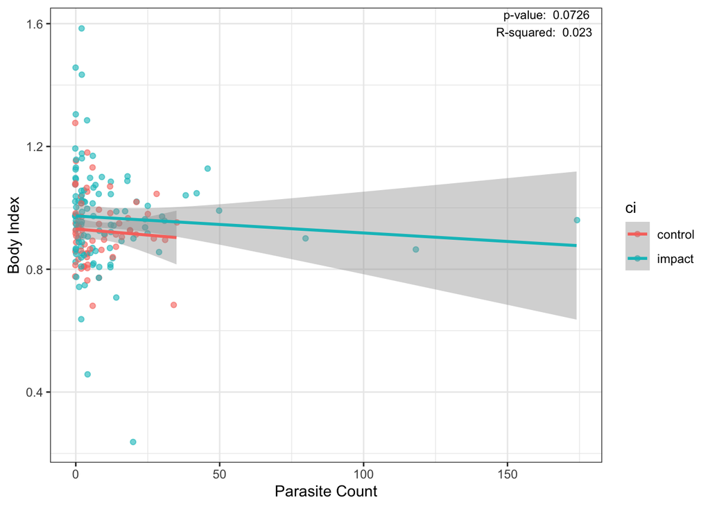

```r
# plot condition factor vs parasite burden in total plus CI
# Extract p-value and R-squared
ciimpact_p_value <- summary(fcf_notath_lm)$coefficients[3, 4]  # p-value for ciimpact
r_squared <- summary(fcf_notath_lm)$r.squared

# Create the plot with jitter and add annotations
ggplot(N.atherinoides.data.fcf, aes(x = psite_count, y = body_index_notath, color = ci)) +
  geom_jitter(width = 0.2, height = 0, alpha = 0.6) +
  xlab("Parasite Count") +
  ylab("Body Index") +
  theme_bw() +
  stat_smooth(method = "lm") +
  annotate("text", x = Inf, y = Inf, label = paste("p-value: ", format(ciimpact_p_value, digits = 3),
                                                   "\nR-squared: ", format(r_squared, digits = 3)),
           hjust = 1.1, vjust = 1.1, size = 3, color = "black")
```

### Discussion

- why are fish in the impact category assocaited with a higher fcf compared to those in the control category when accounting for parasite count?

# Question 2

### Modify datasets to refect only parasites that are able to occur in larval and adult stages in the host.

- we are doing this because in order to have a truly comparable dataset of parasites and their association with host body condition, we need to analyze parasites in a uniform way that does not skew the data one direction or another. For example, if you look at trematode parasites, both metacercaria and adult trematodes can live within a fish host. Now, compare that to monogenes who only occur as adults in the fish host. Because their larval stage will not occur in these fish hosts, by including them in our analyses we will be skewing the adult subset of parasites high. The monogenes have no larval counterpart in the fish, so they will always push the adult count higher. By removing monogenes from our analyses, we will have an even ground to compare larval and adult parasites. Therefore, parasites to **NOT** include in our analyses are:
- monogenes
- copepods
- acanthocephalans
- myxozoans

- make sure you name all these new datasets and frames something different from what you named them above (that way we can still run all the analyses in total without losing any of the previous ones)

## still contains percina – need to add percina

#### Model formula for Question 2

$$K_i\sim life\ stage + parasite\ count\ + ci\ + (1|fish\ species)\ +
(1|catalog\ number)$$
- random effects account for things that may be happening to influence the associations we are testing. By including the random effects, we are testing for and proving that autocorrelation (things that will produce similarities/associations in the data in the background) is not playing a role in skewing the model

### Test the model for Question 2

```r
# check how the different variables are interacting with each other
crosstab <- full.data.stages %>%
  count(life_stage, psite_count)
crosstab_table <- crosstab %>%
  pivot_wider(names_from = psite_count, values_from = n, values_fill = list(n = 0))
view(crosstab_table)

# run the model
summary(q2m <- lmer(fcf ~ life_stage + psite_count + ci + (1|fish_sp_x)+ (1|catalog_number), data = full.data.stages))
```

```
## Linear mixed model fit by REML. t-tests use Satterthwaite's method [
## lmerModLmerTest]
## Formula: fcf ~ life_stage + psite_count + ci + (1 | fish_sp_x) + (1 |
##     catalog_number)
##    Data: full.data.stages
##
## REML criterion at convergence: -3315.8
##
## Scaled residuals:
##     Min      1Q  Median      3Q     Max
## -5.1973 -0.4792 -0.0108  0.4675  4.9402
##
## Random effects:
##  Groups         Name        Variance Std.Dev.
##  catalog_number (Intercept) 0.03081  0.1755
##  fish_sp_x      (Intercept) 0.08634  0.2938
##  Residual                   0.04710  0.2170
## Number of obs: 19419, groups:  catalog_number, 215; fish_sp_x, 5
##
## Fixed effects:
##                    Estimate Std. Error         df t value Pr(>|t|)
## (Intercept)       1.342e+00  1.327e-01  4.087e+00  10.115 0.000482 ***
## life_stageadult   1.152e-03  1.075e-02  1.922e+04   0.107 0.914642
## life_stagelarval -1.412e-03  8.960e-03  1.921e+04  -0.158 0.874823
## psite_count      -4.933e-06  1.489e-04  1.921e+04  -0.033 0.973566
## ciimpact          5.885e-02  2.212e-02  3.407e+02   2.661 0.008166 **
## ---
## Signif. codes:  0 '***' 0.001 '**' 0.01 '*' 0.05 '.' 0.1 ' ' 1
##
## Correlation of Fixed Effects:
##             (Intr) lf_stgd lf_stgl pst_cn
## life_stgdlt -0.002
## lif_stglrvl -0.002  0.066
## psite_count  0.000 -0.116  -0.321
## ciimpact    -0.104  0.000   0.000  -0.002
```

```r
# check colinearity using vif function --> GVIF^(1/(2*Df)) less than 10 means model is ok concerning colinearity (under 5 is acceptable generally)
vif(q2m)
```

```
##                 GVIF Df GVIF^(1/(2*Df))
## life_stage  1.126027  2        1.030118
## psite_count 1.126033  1        1.061147
## ci          1.000006  1        1.000003
```

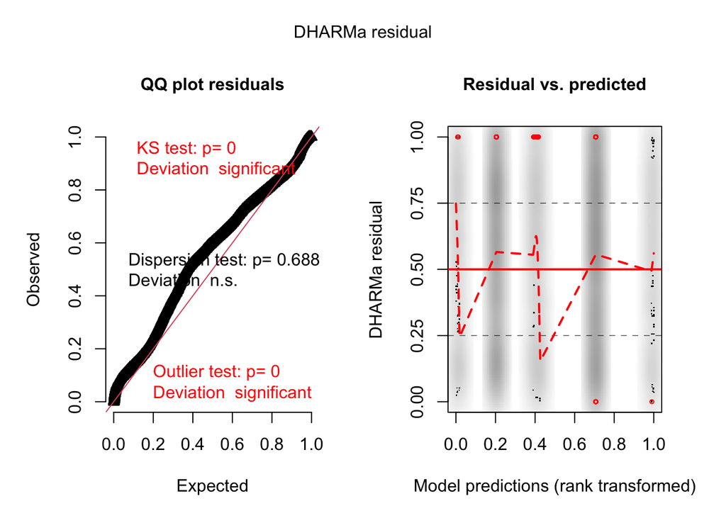

```r
# check how the model fits
s2=simulateResiduals(fittedModel=q2m,n=250)
plot(s2)
```

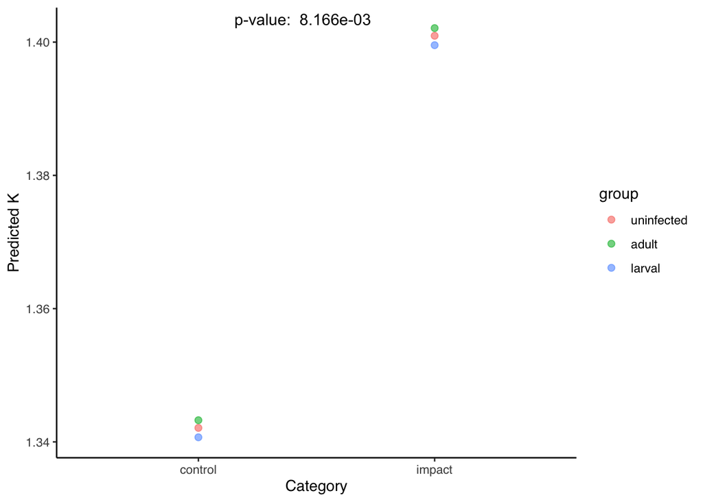

```r
# Generate predictions
mydf <- ggpredict(q2m, terms = c("ci", "life_stage"))

# Define the theme
apatheme <- theme_bw(base_size = 11, base_family = "sans") +
  theme(panel.grid.major = element_blank(),
        panel.grid.minor = element_blank(),
        panel.border = element_blank(),
        axis.line = element_line())

# Extracted values
p_value_ciimpact <- 0.008166  # Example value; replace with actual extracted value

# Create the plot with annotations
ggplot(mydf, aes(x = x, y = predicted, color = group)) +
  geom_point(alpha = 0.6, size = 2) +
  labs(x = 'Category', y = 'Predicted K', title = NULL) +
  annotate("text", x = Inf, y = Inf, label = paste("p-value: ", format(p_value_ciimpact, scientific = TRUE)),
           hjust = 2.5, vjust = 1.5, size = 4, color = "black") +
  apatheme
```

### Discussion

- why are fish in the impact category assocaited with a higher fcf compared to those in the control category when accounting for parasite count, and life stage of parasites?

## Question 3

- Remove from the dataframe the parasites that can only occur as either an adult or a larvae in the host
- contains option for what parasite taxon is present